# This analysis uses the Titanic dataset

## Questions posed

1. Is there any difference in survival rates between different passenger classes?
2. Who had a better survival rate: men or women?
3. Did passengers who traveled as part of a family have a better chance of surviving?
4. Did any particular age group have a better chance of surviving?
5. Does the rate of survival for older passengers vary greatly across different passenger classes?
6. Does the survival rate vary by port of embarkation?
7. Does the survival rate vary by passenger class as well as sex?
8. Is there any relationship between port of embarkation and passenger class?
9. Is there a statistically significant difference between average ages of male and female survivors?
10. Is there a statistically significant difference between average fares paid by survivors and non-survivors?

## Initial Data Exploration

- There are 891 records; all 891 have valid IDs, survivor info, passenger class, names, sex, family, ticket and fare information
- However, only 714 have valid age records, 204 have valid cabin numbers and 889 have valid embarkation records. The remaining passengers have missing values for these records

```python
# Importing and reading the Titanic dataset
import pandas as pd
import numpy as np
import matplotlib.pyplot as plt
filename = '/Users/smitav/Downloads/titanic_data.csv'
titanic_pd = pd.read_csv(filename, delimiter = ',', index_col = 'PassengerId')

# Displaying the last 5 records: we can see that there are 891 records
titanic_pd.tail()
```

| PassengerId | Survived | Pclass | Name | Sex | Age | SibSp | Parch | Ticket | Fare | Cabin | Embarked |
| --- | --- | --- | --- | --- | --- | --- | --- | --- | --- | --- | --- |
| 887 | 0 | 2 | Montvila, Rev. Juozas | male | 27.0 | 0 | 0 | 211536 | 13.00 | NaN | S |
| 888 | 1 | 1 | Graham, Miss. Margaret Edith | female | 19.0 | 0 | 0 | 112053 | 30.00 | B42 | S |
| 889 | 0 | 3 | Johnston, Miss. Catherine Helen "Carrie" | female | NaN | 1 | 2 | W./C. 6607 | 23.45 | NaN | S |
| 890 | 1 | 1 | Behr, Mr. Karl Howell | male | 26.0 | 0 | 0 | 111369 | 30.00 | C148 | C |
| 891 | 0 | 3 | Dooley, Mr. Patrick | male | 32.0 | 0 | 0 | 370376 | 7.75 | NaN | Q |

#### Quick look at the data types of the variables

```python
# Look at data types of variables.
titanic_pd.info()
```

```
<class 'pandas.core.frame.DataFrame'>
Int64Index: 891 entries, 1 to 891
Data columns (total 11 columns):
Survived    891 non-null int64
Pclass      891 non-null int64
Name        891 non-null object
Sex         891 non-null object
Age         714 non-null float64
SibSp       891 non-null int64
Parch       891 non-null int64
Ticket      891 non-null object
Fare        891 non-null float64
Cabin       204 non-null object
Embarked    889 non-null object
dtypes: float64(2), int64(4), object(5)
memory usage: 83.5+ KB
```

#### Descriptive Statistics for Numeric Variables

- Age has a few NaN values. Need to understand why - most likely these are the missing values.

```python
# Descriptive statistics for the numeric variables
titanic_pd.describe()
```

|  | Survived | Pclass | Age | SibSp | Parch | Fare |
| --- | --- | --- | --- | --- | --- | --- |
| count | 891.000000 | 891.000000 | 714.000000 | 891.000000 | 891.000000 | 891.000000 |
| mean | 0.383838 | 2.308642 | 29.699118 | 0.523008 | 0.381594 | 32.204208 |
| std | 0.486592 | 0.836071 | 14.526497 | 1.102743 | 0.806057 | 49.693429 |
| min | 0.000000 | 1.000000 | 0.420000 | 0.000000 | 0.000000 | 0.000000 |
| 25% | 0.000000 | 2.000000 | NaN | 0.000000 | 0.000000 | 7.910400 |
| 50% | 0.000000 | 3.000000 | NaN | 0.000000 | 0.000000 | 14.454200 |
| 75% | 1.000000 | 3.000000 | NaN | 1.000000 | 0.000000 | 31.000000 |
| max | 1.000000 | 3.000000 | 80.000000 | 8.000000 | 6.000000 | 512.329200 |

#### Numerical variables Histograms: Some insights

- The median age seems to be between 20 and 30
- More people perished than survived
- Most passengers paid less than 50 pounds
- There are a few outliers that have paid around 500 pounds for their journey

```
array([[<matplotlib.axes._subplots.AxesSubplot object at 0x132f66a90>,
        <matplotlib.axes._subplots.AxesSubplot object at 0x132fe8790>]], dtype=object)
```

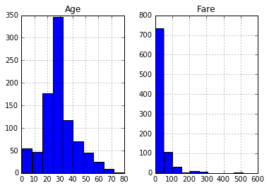

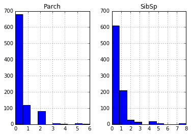

```python
# Histogram of Numerical variables
%matplotlib inline
titanic_pd.hist(['Age', 'Fare'])
print "\n"
titanic_pd.hist(['SibSp', 'Parch'])
```

#### Categorical Variable Frequency Plots

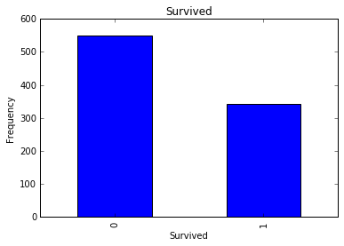

```python
ax = titanic_pd.Survived.value_counts().plot(kind='bar')
ax.set(xlabel="Survived",ylabel="Frequency",title="Survived")
```

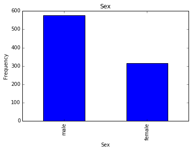

```python
ax = titanic_pd.Sex.value_counts().plot(kind='bar')
ax.set(xlabel="Sex",ylabel="Frequency",title="Sex")
```

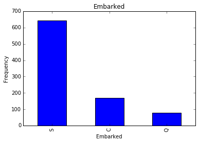

```python
ax = titanic_pd.Embarked.value_counts().plot(kind='bar')
ax.set(xlabel="Embarked",ylabel="Frequency",title="Embarked")
```

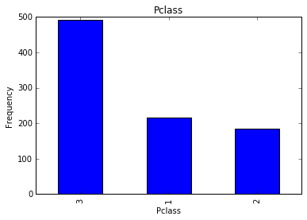

```python
ax = titanic_pd.Pclass.value_counts().plot(kind='bar')
ax.set(xlabel="Pclass",ylabel="Frequency",title="Pclass")
```

## Data Transformations

#### Cabin column

As the cabin column has only 204 values and is not particularly insightful, I am going to drop this column entirely from the dataframe

```python
titanic_pd.drop('Cabin', axis=1, inplace=True)
```

#### Ticket column

Similarly, it looks like the variable 'Ticket' also has mostly unique values, with the highest frequency of a ticket number being 6, and 1 being the most common frequency. Hence, I will drop this variable as well from the dataset.

```python
titanic_pd.drop('Ticket', axis=1, inplace=True)
```

#### Age Group column

I am going to create a new categorical/nominal variable called Age_Group that categorizes age into buckets based on the histogram seen above

```python
def AgeGroup(row):
    if row['Age'] < 15:
        return 'Children'
    elif row['Age'] < 25:
        return "Youth"
    elif row['Age'] < 35:
        return "YoungAdult"
    elif row['Age'] < 50:
        return "MiddleAged"
    elif row['Age'] >= 50:
        return "ElderlyOld"

titanic_pd['Age_Group'] = titanic_pd.apply(AgeGroup, axis = 1)
```

#### Family column

I am going to create a new boolean variable called Family based on whether the SibSp and Parch are 0 or not

```python
def Family(row):
    if row['SibSp'] > 0 or row['Parch'] > 0:
        return 1
    else:
        return 0

titanic_pd['Family'] = titanic_pd.apply(Family, axis = 1)
```

#### Checking updated dataset

```python
titanic_pd.head(n=3)
```

| PassengerId | Survived | Pclass | Name | Sex | Age | SibSp | Parch | Fare | Embarked | Age_Group | Family |
| --- | --- | --- | --- | --- | --- | --- | --- | --- | --- | --- | --- |
| 1 | 0 | 3 | Braund, Mr. Owen Harris | male | 22.0 | 1 | 0 | 7.2500 | S | Youth | 1 |
| 2 | 1 | 1 | Cumings, Mrs. John Bradley (Florence Briggs Th... | female | 38.0 | 1 | 0 | 71.2833 | C | MiddleAged | 1 |
| 3 | 1 | 3 | Heikkinen, Miss. Laina | female | 26.0 | 0 | 0 | 7.9250 | S | YoungAdult | 0 |

## Missing Data

- As the variable 'Age' has many values missing, and it is an important independent variable, I need to fill in the missing values. Filling with just 0 is odd as no one is really 0 years old. I will fill with the median value of the existing age data based on the age histogram.

```python
# Median age
median_age = titanic_pd['Age'].median()
# Fill the missing values with the median age
titanic_pd['Age'].fillna(median_age, inplace= True)
titanic_pd.describe()
```

|  | Survived | Pclass | Age | SibSp | Parch | Fare | Family |
| --- | --- | --- | --- | --- | --- | --- | --- |
| count | 891.000000 | 891.000000 | 891.000000 | 891.000000 | 891.000000 | 891.000000 | 891.000000 |
| mean | 0.383838 | 2.308642 | 29.361582 | 0.523008 | 0.381594 | 32.204208 | 0.397306 |
| std | 0.486592 | 0.836071 | 13.019697 | 1.102743 | 0.806057 | 49.693429 | 0.489615 |
| min | 0.000000 | 1.000000 | 0.420000 | 0.000000 | 0.000000 | 0.000000 | 0.000000 |
| 25% | 0.000000 | 2.000000 | 22.000000 | 0.000000 | 0.000000 | 7.910400 | 0.000000 |
| 50% | 0.000000 | 3.000000 | 28.000000 | 0.000000 | 0.000000 | 14.454200 | 0.000000 |
| 75% | 1.000000 | 3.000000 | 35.000000 | 1.000000 | 0.000000 | 31.000000 | 1.000000 |
| max | 1.000000 | 3.000000 | 80.000000 | 8.000000 | 6.000000 | 512.329200 | 1.000000 |

## Analyses

#### Survivors

Initial look at the number of survivors of the Titanic. I can see that only 38% of the population survived

```python
survivors = pd.crosstab(index = titanic_pd['Survived'],
            columns = 'count',
            margins = True)
survivors/survivors.ix["All"]
```

| col_0 Survived | count | All |
| --- | --- | --- |
| 0 | 0.616162 | 0.616162 |
| 1 | 0.383838 | 0.383838 |
| All | 1.000000 | 1.000000 |

Next, I am going to look at whether there are differences in survival rates across sex, passenger class, embarked port, family and age group. In order to do that I will define a couple of functions and use them across the different variables. Both of these functions calculate crosstabs for 2 or 3 variables for a given dataset. The cross tabulation of various variables against each other will help me see the breakdowns and relations between these variables.

#### Function to determine survival proportions for 1 variable

```python
def CrossProp(df, Outcome, Variable):
    outcome_by_var = pd.crosstab(index = df[Outcome],
            columns = df[Variable],
            margins = True)
    print "Proportion of %s by %s" %(Outcome, Variable), "\n"
    print outcome_by_var, "\n"
    print outcome_by_var/outcome_by_var.ix["All"]
```

#### Function to determine survival proportions for 2 variables

```python
def CrossProp2(df, Outcome, Variable1, Variable2):
    outcome_by_var = pd.crosstab(index = df[Outcome],
            columns = [df[Variable1],df[Variable2]],
            margins = True)
    print "Proportion of %s by %s and %s" %(Outcome, Variable1, Variable2), "\n"
    print outcome_by_var, "\n"
    print outcome_by_var/outcome_by_var.ix["All"]
```

### Q1. Is there any difference in survival rates between different passenger classes?

I first look at the breakdown of survived versus not-survived numbers for each passenger class

```python
CrossProp(titanic_pd, 'Survived', 'Pclass')
```

```
Proportion of Survived by Pclass

Pclass      1    2    3  All
Survived
0          80   97  372  549
1         136   87  119  342
All       216  184  491  891

Pclass          1         2         3       All
Survived
0         0.37037  0.527174  0.757637  0.616162
1         0.62963  0.472826  0.242363  0.383838
All       1.00000  1.000000  1.000000  1.000000
```

From the above proportions, it looks like the survival rates are quite different across the different passenger classes. It is highest at 63% for 1st class passenegers, falls to 47% for 2nd class and is a very low 24% for 3rd class passengers.

### Q2: Who had a better survival rate: men or women?

Looking at just the raw numbers of male vs female survivors:

```python
titanic_groupbysex = titanic_pd.groupby('Sex')
titanic_groupbysex['Survived'].sum()
```

```
Sex
female    233
male      109
Name: Survived, dtype: int64
```

I can see that more than twice as many women survived the Titanic's maiden journey, compared to men

Looking next at the **proportions** of each sex that survived:

```python
CrossProp(titanic_pd, 'Survived', 'Sex')
```

```
Proportion of Survived by Sex

Sex       female  male  All
Survived
0             81   468  549
1            233   109  342
All          314   577  891

Sex         female      male       All
Survived
0         0.257962  0.811092  0.616162
1         0.742038  0.188908  0.383838
All       1.000000  1.000000  1.000000
```

I can see that **74% of female passengers** survived the journey as compared to only *19% of male passengers.*

### Q3. Did passengers who traveled as part of a family have a better chance of surviving?

```python
CrossProp(titanic_pd, 'Survived', 'Family')
```

```
Proportion of Survived by Family

Family      0    1  All
Survived
0         374  175  549
1         163  179  342
All       537  354  891

Family           0        1       All
Survived
0         0.696462  0.49435  0.616162
1         0.303538  0.50565  0.383838
All       1.000000  1.00000  1.000000
```

It looks like passengers that were part of a family had a 50:50 rate of survival, while those who traveled alone had a higher rate of perishing

### Q4. Did any particular age group have a better chance of surviving?

I have added an additional column 'Age_Group' as a nominal variable that buckets people into various age group categories.

```python
CrossProp(titanic_pd, 'Survived', 'Age_Group')
```

```
Proportion of Survived by Age_Group

Age_Group  Children  ElderlyOld  MiddleAged  YoungAdult  Youth  All
Survived
0                33          47          94         123    127  424
1                45          27          67          78     73  290
All              78          74         161         201    200  714

Age_Group  Children  ElderlyOld  MiddleAged  YoungAdult  Youth       All
Survived
0          0.423077    0.635135    0.583851     0.61194  0.635  0.593838
1          0.576923    0.364865    0.416149     0.38806  0.365  0.406162
All        1.000000    1.000000    1.000000     1.00000  1.000  1.000000
```

I am now curious to see if the different age groups had different survival rates across passenger classes - in particular for the elderly.

### Q5. Does the rate of survival for the elderly and the old (aged 50 and above) vary greatly across different passenger classes?

```python
old_people_df = titanic_pd[titanic_pd.Age_Group.isin(["ElderlyOld"])]
CrossProp(old_people_df, 'Survived', 'Pclass')
```

```
Proportion of Survived by Pclass

Pclass     1   2   3  All
Survived
0         24  13  10   47
1         20   6   1   27
All       44  19  11   74

Pclass           1         2         3       All
Survived
0         0.545455  0.684211  0.909091  0.635135
1         0.454545  0.315789  0.090909  0.364865
All       1.000000  1.000000  1.000000  1.000000
```

### Q6. Does the survival rate vary by port of embarkation?

```python
CrossProp(titanic_pd, 'Survived', 'Embarked')
```

```
Proportion of Survived by Embarked

Embarked    C   Q    S  All
Survived
0          75  47  427  549
1          93  30  217  340
All       168  77  644  889

Embarked         C        Q         S       All
Survived
0         0.446429  0.61039  0.663043  0.617548
1         0.553571  0.38961  0.336957  0.382452
All       1.000000  1.00000  1.000000  1.000000
```

It appears that passengers embarking at port Cherbourg had a higher rate of survival (55%) compared to the average survival rate of 38%

### Q7. Does the survival rate vary by passenger class as well as sex?

```python
CrossProp2(titanic_pd, 'Survived', 'Pclass', 'Sex')
```

```
Proportion of Survived by Pclass and Sex

Pclass        1           2           3       All
Sex      female male female male female male
Survived
0             3   77      6   91     72  300  549
1            91   45     70   17     72   47  342
All          94  122     76  108    144  347  891

Pclass           1                   2                3                 All
Sex         female      male    female      male female      male
Survived
0         0.031915  0.631148  0.078947  0.842593    0.5  0.864553  0.616162
1         0.968085  0.368852  0.921053  0.157407    0.5  0.135447  0.383838
All       1.000000  1.000000  1.000000  1.000000    1.0  1.000000  1.000000
```

From the above, I see that women in 1st and 2nd class have a much higher rate of survival compared to anyone else; women in 3rd class have a 50% chance of survival compared to 14% for men in 3rd class.

### Q8. Is there any relationship between port of embarkation and passenger class?

```python
CrossProp(titanic_pd, 'Pclass', 'Embarked')
```

```
Proportion of Pclass by Embarked

Embarked    C   Q    S  All
Pclass
1          85   2  127  214
2          17   3  164  184
3          66  72  353  491
All       168  77  644  889

Embarked         C         Q         S       All
Pclass
1         0.505952  0.025974  0.197205  0.240720
2         0.101190  0.038961  0.254658  0.206974
3         0.392857  0.935065  0.548137  0.552306
All       1.000000  1.000000  1.000000  1.000000
```

- The Titanic sailed from Southampton in England and it looks like more than half the passengers were in 3rd class. Most passengers boarded at this port, as seen earlier.
- The next stop was Cherbourg in France where fewer passengers got on, but the majority were in 1st class (50% of passengers who got on at Cherbourg were in 1st class).
- It looks like more 3rd class passengers than either other class got on the Titanic at Queenstown in Ireland. Many of the passengers were new immigrants to the United States of America.

### Q9. Is there a statistically significant difference between average ages of male and female survivors?

- Null hypothesis: average age of male survivors (Am) = average age of female survivors (Af)
- Alternative hypothesis: Am != Af

First I will create a subset of the data that comprises only survivors. There are 342 survivors.

```python
survivors = titanic_pd[titanic_pd.Survived > 0]
len(survivors)
```

```
342
```

I will use the t-test for 2 independent samples to test my hypothesis.

*Male survivor ages:*

```python
males = survivors[survivors.Sex == 'male']
males_age = np.array(males['Age'])
print 'Number of male survivors is: %d' %(len(males_age))
print 'Mean male survivor age is: %d' %(males_age.mean())
```

```
Number of male survivors is: 109
Mean male survivor age is: 27
```

*Female Survivor Ages:*

```python
females = survivors[survivors.Sex == 'female']
females_age = np.array(females['Age'])
print 'Number of female survivors is: %d' %(len(females_age))
print 'Mean female survivor age is: %d' %(females_age.mean())
```

```
Number of female survivors is: 233
Mean female survivor age is: 28
```

*T-Test*

- The package scipy has a statistical subset stats, which has a function ttest_ind to check for this.
- It needs 2 input arrays for male and female ages.
- I will perform the test at an alpha value of 0.05 or a confidence of 95%. This means that the p-value needs to be less than 0.05 for the null hypothesis to be rejected.
- The output of the test is of the format: (t-test, p-value)

```python
import scipy.stats as stats
stats.ttest_ind(males_age, females_age)
```

```
Ttest_indResult(statistic=-0.8350794934208513, pvalue=0.40425935251398093)
```

I see that the pvalue is 0.404, much higher than 0.05, and hence I cannot reject the null hypothesis at a significance level (alpha level) of 0.05 or 95% confidence.

Thus I conclude that there is no significant difference between mean ages of male and female survivors of the Titanic. However, I must keep in mind that my age data contains some artificial values (median age of 28 was inserted into missing data points) and so I do not want to make any strong conclusions.

### Q10. Is there a statistically significant difference between average fares paid by survivors and non-survivors?

- Null hypothesis: average fare paid by survivors (Fs) = average fare paid by non-survivors (Fns)
- Alternative hypothesis: Fs != Fns

First I need to split the Titanic data into 2 datasets for survivors and non-survivors. I already have the survivors dataset from the previous questions and will reuse that.

I obtain the non-survivors data as seen below. There are 549 non-survivors.

```python
non_survivors = titanic_pd[titanic_pd.Survived == 0]
len(non_survivors)
```

```
549
```

Next I obtain the fares for survivors and non survivors and store them in numpy arrays.

```python
survivors_fare = np.array(survivors['Fare'])
print 'Mean fare for survivors is: %d' %(survivors_fare.mean())
```

```
Mean fare for survivors is: 48
```

```python
nonsurvivors_fare = np.array(non_survivors['Fare'])
print 'Mean fare for non-survivors is: %d' %(nonsurvivors_fare.mean())
```

```
Mean fare for non-survivors is: 22
```

*Testing the hypothesis*

- I perform another independent 2 sample t-test using the scipy stats library as seen in the analysis for the previous question.
- It needs 2 input arrays for survivor and non-survivor fares.
- I will perform the test at an alpha value of 0.05 or a confidence of 95%. This means that the p-value needs to be less than 0.05 for the null hypothesis to be rejected.
- The output of the test is of the format: (t-test, p-value)

```python
stats.ttest_ind(survivors_fare, nonsurvivors_fare)
```

```
Ttest_indResult(statistic=7.9391916608710549, pvalue=6.1201893419241981e-15)
```

As seen above, the p-value is very small, much lower than the t-critical value of 0.05 (95% confidence) and lower than even the t-critical value of 0.01 (99% confidence) if I wanted a higher confidence. I do not accept the null hypothesis and conclude that the alternate hypothesis is true.

Thus I can see that the fares paid by survivors of the Titanic were much different (in fact, much higher) than those paid by non-survivors.

#### Visual Representation of Fares for Survivors versus Non-Survivors

I want to show the difference in fares paid by survivors versus non-survivors in a visual format as well.

- I have used a density chart below that shows how the fare distributions differ: for survivors, the distribution is fatter and tapers off at around 200 pounds; it also includes the highest fares (512 pounds).
- The distribution for non-survivors is much skinnier and tapers off around 100 pounds.

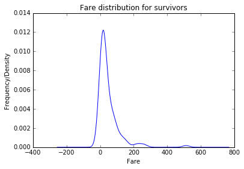

```python
ax = survivors['Fare'].plot(kind='density')
ax.set(xlabel = "Fare", ylabel = 'Frequency/Density', title = "Fare distribution for survivors")
```

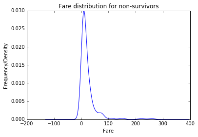

```python
ax = non_survivors['Fare'].plot(kind='density')
ax.set(xlabel = "Fare", ylabel = 'Frequency/Density', title = "Fare distribution for non-survivors")
```

## SOURCES

- Udacity Introduction to Statistics Course
- Scipy documentation: http://docs.scipy.org/doc/scipy-0.15.1/reference/generated/scipy.stats.ttest_ind.html
- Pandas plots documentation: http://pandas.pydata.org/pandas-docs/stable/visualization.html
- Pandas documentation: http://pandas.pydata.org/pandas-docs/version/0.15.2/index.html
- Titanic wiki page: https://en.wikipedia.org/wiki/RMS_Titanic